# Lab-3.1: Image data and Convolutional neural networks in Keras

Author: J. Hickman

- In this lab we do the following
  - (1) An introduction to image data
  - (2) Use Keras to train a CNN using MNIST (and CIFAR10) to do multi-class classification.

**Submission:**

- You need to upload ONE document to Canvas when you are done
  - (1) A PDF (or HTML) of the completed form of this notebook
- The final uploaded version should NOT have any code-errors present
- All outputs must be visible in the uploaded version, including code-cell outputs, images, graphs, etc

## Part-1: Introduction to image data

Before diving into CNN training we will do an brief introduction to image data and common image data-sets

### Import packages

```python
import numpy as np
import keras
import tensorflow as tf
import matplotlib.pyplot as plt
```

### Grayscale images

The simplest possible image is a grayscale image, stored in a matrix, i.e. a rank-2 tensor.

Gray scale images have only one color channel.

This color channel is the grayscale number which runs from 0 (black) to 255 (white)

The gray-scale values can also run from 0 to 1 if the image is normalized.

The following is a very low resolution image of a handwritten digit "5"

```python
#DEFINE IMAGE (HAND WRITTEN DIGIT 5)
x=[[0   ,0   ,0   ,0   ,0   ,0   ,0   ,0   ,0   ,0],
 [  0   ,0   ,0   ,1   ,5   ,14  ,28  ,38  ,18  ,0],
 [  0   ,0   ,25  ,140 ,190 ,207 ,162 ,124 ,38  ,0],
 [  0   ,0   ,13  ,108 ,204 ,58  ,40  ,1   ,0   ,0],
 [  0   ,0   ,0   ,5   ,136 ,72  ,8   ,0   ,0   ,0],
 [  0   ,0   ,0   ,0   ,16  ,142 ,143 ,11  ,0   ,0],
 [  0   ,0   ,0   ,0   ,18  ,101 ,219 ,39  ,0   ,0],
 [  0   ,0   ,19  ,86  ,196 ,188 ,80  ,4   ,0   ,0],
 [  0   ,52  ,176 ,183 ,95 , 11  ,0   ,0   ,0   ,0],
 [  0   ,2   ,7   ,3   ,0   ,0   ,0   ,0   ,0   ,0]]
x=np.array(x)
```

```python
# EXPLORE IMAGE SHAPE
print("SHAPE:",x.shape)

# PLOT IMAGE
plt.imshow(x, cmap=plt.cm.gray); plt.show()
```

[output not shown]

```
SHAPE: (10, 10)
```

Technically a 2D image is a mathematical function, specifically a scalar field g=g(x,y), where g is the grayscale number and (x,y) represents the position in the image.

i.e. given a position in the matrix (location in image in the x-y plane) return the gray-scale number (scalar)

This can be plotted as a surface with two independent variables (x,y) and one independent response variable z, as shown below.

If you wanted, you could compute the gradient of this function using finite difference in 2 dimensions. (this forms a convolutional filter)

Regions of "steep" gradient correspond to edges. This derivative based method was the origin of many "pre-deep learning" edge detection methods.

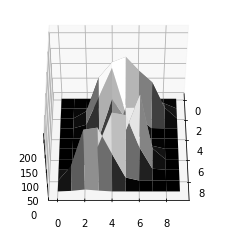

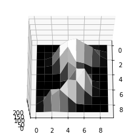

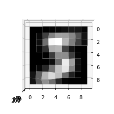

```python
#SURFACE PLOT
def surface_plot(image,angle=90):
    # create the x and y coordinate arrays (here we just use pixel indices)
    xx, yy = np.mgrid[0:image.shape[0], 0:image.shape[1]]
    fig = plt.figure()
    ax = fig.add_subplot(111, projection='3d')
    ax.plot_surface(xx, yy, image[:,:] ,rstride=1, cstride=1, cmap=plt.cm.gray,linewidth=0)
    ax.view_init(elev=angle, azim=0)
    plt.show()

surface_plot(x,50)
surface_plot(x,70)
surface_plot(x,90)
```

It is common to give the color channel it's own dimension by converting the matrix (rank-2 tensor) to a rank-3 tensor.

The color channels are typically stored in either the last or first dimension of the matrix

- KERAS (and PIL) CONVENTION --> img.shape=(H,W,C)
- PYTORCH CONVENTION --> img.shape=(C,H,W)
- H=the height of the image (number of pixels)
- W=the width of the image (number of pixels)
- C=number of color channels

For this lab we will use the Keras convention, next week we will use Py-Torch

```python
x=x.reshape(x.shape[0],x.shape[1], 1)

# EXPLORE IMAGE SHAPE
print("SHAPE:",x.shape)

# PLOT IMAGE (expects a matrix)
plt.imshow(x, cmap=plt.cm.gray); plt.show()
```

[output not shown]

```
SHAPE: (10, 10, 1)
```

**Assignment 3.1.1**

Write a utility function called `def explore_image(image):`.

Where `image` is a numpy array with shape (H,W,C).

This function should do the following

(1) print the following information about the provided numpy array (tensor)

```
TYPE: <class 'numpy.ndarray'>
SHAPE: (10, 10, 1)
NUMBER OF PIXELS: 100
NUMBER OF TENSOR ENTRIES: 100
N CHANNELS 1
MIN: 0
MAX: 219
TYPE: int64
```

(2) Plot either a grayscale image or a color image based on the number of channels in the image.

```python
import torch
```

```python
# INSERT CODE FOR UTILITY FUNCTION HERE
import numpy as np
def explore_image(image):
    #tensor = torch.from_numpy(image)
    print('TYPE: ', type(image))
    print('SHAPE: ', image.shape)
    print('NUMBER OF PIXELS: ', image.shape[0]*image.shape[1])
    print('NUMBER OF TENSOR ENTRIES: ', image.size)
    if len(image.shape) == 2:
        image = image.reshape(image.shape[0],image.shape[1], 1)
    print('N CHANNELS: ', image.shape[2])
    print('MIN: ', image.min())
    print('MAX: ', image.max())
    print('TYPE: ', image.dtype)

    if image.shape[2] == 1:
        plt.imshow(image, cmap=plt.cm.gray)
        plt.show()
    else:
        plt.imshow(image, cmap=plt.cm.rainbow)
        plt.show()
```

```python
# TEST UTILITY FUNCTION
explore_image(x)
```

[output not shown]

```
TYPE:  <class 'numpy.ndarray'>
SHAPE:  (10, 10, 1)
NUMBER OF PIXELS:  100
NUMBER OF TENSOR ENTRIES:  100
N CHANNELS:  1
MIN:  0
MAX:  219
TYPE:  int64
```

Any 2D matrix can be visualized as an image, for example a heatmap of a correlation matrix

"White noise" (i.e. TV static) is an image where all pixel values are random numbers

```
TYPE:  <class 'numpy.ndarray'>
SHAPE:  (400, 400, 1)
NUMBER OF PIXELS:  160000
NUMBER OF TENSOR ENTRIES:  160000
N CHANNELS:  1
MIN:  0
MAX:  254
TYPE:  int64
```

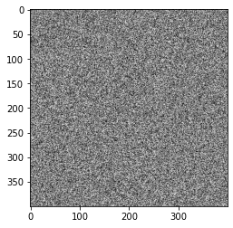

```python
nx=400  #number of pixels in x
ny=400  #number of pixels in y

x =(np.random.uniform(0,255,nx*ny).reshape(ny,nx,1)).astype(int)
explore_image(x)
```

### Color images

Color images have 3 color channels for the three primary colors (R,G,B)

Therefore they must be stored as rank-3 tensors (i.e. a stack of 3 matrices on top of each other)

```
TYPE:  <class 'numpy.ndarray'>
SHAPE:  (400, 400, 3)
NUMBER OF PIXELS:  160000
NUMBER OF TENSOR ENTRIES:  480000
N CHANNELS:  3
MIN:  0
MAX:  254
TYPE:  int64
```

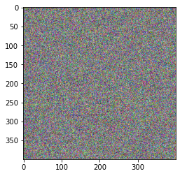

```python
# INSERT CODE TO GENERATE 400x400x3 "COLORED WHITE NOISE MATRIX" AND RUN IT THROUGH "explore_image(x)
nx=400  #number of pixels in x
ny=400  #number of pixels in y

x =(np.random.uniform(0,255,3*nx*ny).reshape(ny,nx,3)).astype(int)
explore_image(x)
```

The following color image was taken with an iPhone, notice that the number of pixels and the number of tensor entries is now different

```
TYPE:  <class 'numpy.ndarray'>
SHAPE:  (930, 743, 3)
NUMBER OF PIXELS:  690990
NUMBER OF TENSOR ENTRIES:  2072970
N CHANNELS:  3
MIN:  0
MAX:  255
TYPE:  uint8
```

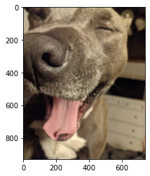

```python
#LOAD IMAGE
x=plt.imread('luna-1.jpeg')
explore_image(x)
```

### Image transformations

There are various transformations we can apply to an image.

We will explore this in more detail next week using the torch-vision library.

#### Cropping

Cropping is just slicing the image into sub-regions

This can be done using standard numpy slicing commands

**Assignment 3.1.2**

- Write code to slice (crop) the image in the following ways and pass them to the "explore_image" function
  - A square centered at the upper left corner of the image showing 40% of the image in the H and W dimensions
  - A slice with all pixels in the vertical dimension but only horizontal pixels in the range 40% to 60%
  - A slice with all pixels in the horizontal dimension but only vertical pixels in the range 40% to 60%

```
TYPE:  <class 'numpy.ndarray'>
SHAPE:  (372, 297, 3)
NUMBER OF PIXELS:  110484
NUMBER OF TENSOR ENTRIES:  331452
N CHANNELS:  3
MIN:  0
MAX:  238
TYPE:  uint8
```

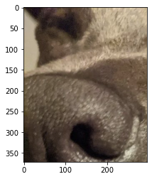

```python
explore_image(x[:int(x.shape[0]*0.4),:int(x.shape[1]*0.4)])
```

```python
explore_image(x[:,int(x.shape[1]*0.4):int(x.shape[1]*0.6)])
```

[output not shown]

```
TYPE:  <class 'numpy.ndarray'>
SHAPE:  (930, 148, 3)
NUMBER OF PIXELS:  137640
NUMBER OF TENSOR ENTRIES:  412920
N CHANNELS:  3
MIN:  0
MAX:  255
TYPE:  uint8
```

```
TYPE:  <class 'numpy.ndarray'>
SHAPE:  (186, 743, 3)
NUMBER OF PIXELS:  138198
NUMBER OF TENSOR ENTRIES:  414594
N CHANNELS:  3
MIN:  0
MAX:  255
TYPE:  uint8
```

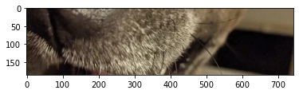

```python
explore_image(x[int(x.shape[0]*0.4):int(x.shape[0]*0.6),:])
```

#### Change image resolution

This can be done using various Python libraries, e.g. cv2, skimage, pil, torch-vision.

We will discuss torch-vision in more detail next week.

`conda install scikit-image`

```
TYPE:  <class 'numpy.ndarray'>
SHAPE:  (93, 74, 3)
NUMBER OF PIXELS:  6882
NUMBER OF TENSOR ENTRIES:  20646
N CHANNELS:  3
MIN:  0.011953580637658204
MAX:  0.984296113733669
TYPE:  float64
```

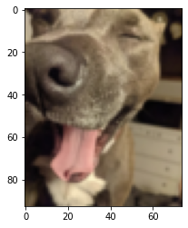

```python
#REDUCE RESOLUTION-1
from skimage.transform import rescale, resize, downscale_local_mean
factor=10
x = resize(x, (x.shape[0] // factor, x.shape[1] // factor), anti_aliasing=True)
explore_image(x)
```

**Assignment 3.1.3**

Write a function `filter(x)` which applies a convolutional filter to the input image.

Do this "manually" using a triple for loop over (channels, H, W) instead of using np.convolve

Use the following edge detection filter: `filter_ED=[[0,-1,0],[-1,4,-1],[0,-1,0]]`

Run the convolved image through `explore_image`

```python
def filter(img, filter_ED):
    #filter_ED=[[0,-1,0],[-1,4,-1],[0,-1,0]]
    filter_ED = np.asarray(filter_ED)
    filter_r = filter_ED.shape[0]
    filter_c = filter_ED.shape[1]

    height =  img.shape[0] - filter_ED.shape[0] + 1
    width =  img.shape[1] - filter_ED.shape[1] + 1
    channel = img.shape[2]

    Z = np.zeros((height, width, channel))

    for c in range(channel):
        for h in range(height):
            for w in range(width):
                new_z = img[h:h+filter_r, w:w+filter_c, c]

                Z[h,w,c] = np.sum(np.multiply(new_z, filter_ED))
    return Z
```

```
Clipping input data to the valid range for imshow with RGB data ([0..1] for floats or [0..255] for integers).
```

```
TYPE:  <class 'numpy.ndarray'>
SHAPE:  (91, 72, 3)
NUMBER OF PIXELS:  6552
NUMBER OF TENSOR ENTRIES:  19656
N CHANNELS:  3
MIN:  -0.5495544038904444
MAX:  0.7356235993140727
TYPE:  float64
```

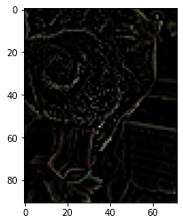

```python
filter_ED=[[0,-1,0],[-1,4,-1],[0,-1,0]]
explore_image(filter(x,filter_ED))
```

## Batches of gray-scale images

Often in deep learning we "stack" many images into a "batch" of samples to accelerate vectorized computation.

This increases the tensor rank by 1 dimension

In this way we can store the entire dataset in one tensor

- KERAS (and PIL) CONVENTION --> dataset.shape=(B,H,W,C)
- PYTORCH CONVENTION --> dataset.shape=(B,C,H,W)
- B=number of samples (batch dimension)
- H=the height of the image (number of pixels)
- W=the width of the image (number of pixels)
- C=number of color channels

### MNIST

MNIST is a is a famous deep-learning data-set with hand-written digits

This is a dataset of 60,000 28x28 grayscale images of the 10 digits, along with a test set of 10,000 images. More info can be found at the MNIST homepage.

loaded from Keras as a Tuple of NumPy arrays: (x_train, y_train), (x_test, y_test).

x_train: uint8 NumPy array of grayscale image data with shapes (60000, 28, 28), containing the training data. Pixel values range from 0 to 255.

y_train: uint8 NumPy array of digit labels (integers in range 0-9) with shape (60000,) for the training data.

x_test: uint8 NumPy array of grayscale image data with shapes (10000, 28, 28), containing the test data. Pixel values range from 0 to 255.

y_test: uint8 NumPy array of digit labels (integers in range 0-9) with shape (10000,) for the test data.

https://keras.io/api/datasets/mnist/

```python
##GET DATASET
(x_train, y_train), (x_test, y_test) = tf.keras.datasets.mnist.load_data()
```

```python
print(x_train.shape)
print(y_train.shape)
```

```
(60000, 28, 28)
(60000,)
```

```python
# RESHAPE
x_test = x_test.reshape((10000, 28, 28, 1))
x_train = x_train.reshape((60000, 28, 28, 1))
```

```python
print(x_test.shape)
print(y_test.shape)
```

```
(10000, 28, 28, 1)
(10000,)
```

```
TYPE:  <class 'numpy.ndarray'>
SHAPE:  (28, 28, 1)
NUMBER OF PIXELS:  784
NUMBER OF TENSOR ENTRIES:  784
N CHANNELS:  1
MIN:  0
MAX:  255
TYPE:  uint8
```

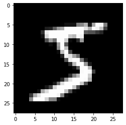

```python
explore_image(x_train[0])
```

```
TYPE:  <class 'numpy.ndarray'>
SHAPE:  (28, 28, 1)
NUMBER OF PIXELS:  784
NUMBER OF TENSOR ENTRIES:  784
N CHANNELS:  1
MIN:  0
MAX:  255
TYPE:  uint8
```

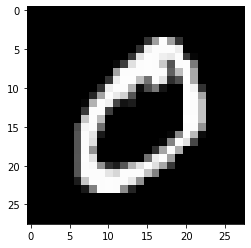

```python
explore_image(x_train[1])
```

**Assignment 3.1.4**

Load balance between the various classes in our dataset is important for any classification problem

Define a function `def CheckCount(data):`

Which counts and outputs the number of samples in each class to make sure that the dataset isn't overly biased towards one class.

Example function output

```
----- TRAINING ------
label = 0     count = 5923
label = 1     count = 6742
label = 2     count = 5958
label = 3     count = 6131
label = 4     count = 5842
label = 5     count = 5421
label = 6     count = 5918
label = 7     count = 6265
label = 8     count = 5851
label = 9     count = 5949
TOTAL = 60000
```

```python
#INSERT CODE TO CHECK LOAD BALANCE OF THE VARIOUS DIGITS (CLASSES)
def CheckCount(data):
    total = 0
    for i,j in zip(np.unique(data,return_counts=True)[0], np.unique(data,return_counts=True)[1]):
        print(f"label = {i}\tcount = {j}")
        total += j
    print(f'TOTAL = {total}')
```

```python
# TEST YOUR FUNCTION TO MAKE SURE IT WORKS
print("\n----- TRAINING ------")
CheckCount(y_train)
print("\n-----   TEST   ------")
CheckCount(y_test)
```

```
----- TRAINING ------
label = 0	count = 5923
label = 1	count = 6742
label = 2	count = 5958
label = 3	count = 6131
label = 4	count = 5842
label = 5	count = 5421
label = 6	count = 5918
label = 7	count = 6265
label = 8	count = 5851
label = 9	count = 5949
TOTAL = 60000

-----   TEST   ------
label = 0	count = 980
label = 1	count = 1135
label = 2	count = 1032
label = 3	count = 1010
label = 4	count = 982
label = 5	count = 892
label = 6	count = 958
label = 7	count = 1028
label = 8	count = 974
label = 9	count = 1009
TOTAL = 10000
```

## Batches of color images

CIFAR10 is a famous deep learning data set. It is similar to MNIST but has color images instead of grayscale

This is a dataset of 50,000 32x32 color training images and 10,000 test images, labeled over 10 categories. See more info at the CIFAR homepage.

The classes are:

- Label Description
- 0 airplane
- 1 automobile
- 2 bird
- 3 cat
- 4 deer
- 5 dog
- 6 frog
- 7 horse
- 8 ship
- 9 truck

tf.keras.datasets.cifar10.load_data() Loads the CIFAR10 dataset.

This command returns a tuple of NumPy arrays: (x_train, y_train), (x_test, y_test).

y_train: uint8 NumPy array of labels (integers in range 0-9) with shape (50000, 1) for the training data.

y_test: uint8 NumPy array of labels (integers in range 0-9) with shape (10000, 1) for the test data.

```python
(x_train, y_train), (x_test, y_test) = tf.keras.datasets.cifar10.load_data()
```

```python
print(x_train.shape)
print(y_train.shape)
```

```
(50000, 32, 32, 3)
(50000, 1)
```

```python
print(x_test.shape)
print(y_test.shape)
```

```
(10000, 32, 32, 3)
(10000, 1)
```

```
TYPE:  <class 'numpy.ndarray'>
SHAPE:  (32, 32, 3)
NUMBER OF PIXELS:  1024
NUMBER OF TENSOR ENTRIES:  3072
N CHANNELS:  3
MIN:  0
MAX:  255
TYPE:  uint8
```

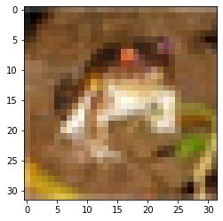

```python
explore_image(x_train[0])
```

```
TYPE:  <class 'numpy.ndarray'>
SHAPE:  (32, 32, 3)
NUMBER OF PIXELS:  1024
NUMBER OF TENSOR ENTRIES:  3072
N CHANNELS:  3
MIN:  5
MAX:  254
TYPE:  uint8
```

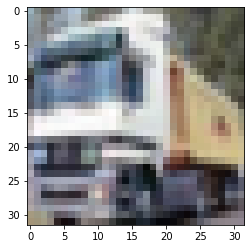

```python
explore_image(x_train[1])
```

```python
print("\n----- TRAINING ------")
CheckCount(y_train)
print("\n-----   TEST   ------")
CheckCount(y_test)
```

```
----- TRAINING ------
label = 0	count = 5000
label = 1	count = 5000
label = 2	count = 5000
label = 3	count = 5000
label = 4	count = 5000
label = 5	count = 5000
label = 6	count = 5000
label = 7	count = 5000
label = 8	count = 5000
label = 9	count = 5000
TOTAL = 50000

-----   TEST   ------
label = 0	count = 1000
label = 1	count = 1000
label = 2	count = 1000
label = 3	count = 1000
label = 4	count = 1000
label = 5	count = 1000
label = 6	count = 1000
label = 7	count = 1000
label = 8	count = 1000
label = 9	count = 1000
TOTAL = 10000
```

## Part-2: Training CNN in Keras

The following trains an CNN on the MNIST data set

#### Import

```python
#MODIFIED FROM CHOLLETT P120
from keras import layers
from keras import models
import numpy as np
import warnings
warnings.filterwarnings("ignore")
```

#### Build CNN model

```python
#-------------------------------------
#BUILD MODEL SEQUENTIALLY (LINEAR STACK)
#-------------------------------------
model = models.Sequential()
model.add(layers.Conv2D(32, (3, 3), activation='relu', input_shape=(28, 28, 1)))
model.add(layers.MaxPooling2D((2, 2)))

model.add(layers.Conv2D(64, (3, 3), activation='relu'))
model.add(layers.MaxPooling2D((2, 2)))
model.add(layers.Conv2D(64, (3, 3), activation='relu'))

model.add(layers.Flatten())
model.add(layers.Dense(64, activation='relu'))
model.add(layers.Dense(10, activation='softmax'))

model.summary()
```

```
Model: "sequential"
_________________________________________________________________
 Layer (type)                Output Shape              Param #
=================================================================
 conv2d (Conv2D)             (None, 26, 26, 32)        320

 max_pooling2d (MaxPooling2D  (None, 13, 13, 32)       0
 )

 conv2d_1 (Conv2D)           (None, 11, 11, 64)        18496

 max_pooling2d_1 (MaxPooling  (None, 5, 5, 64)         0
 2D)

 conv2d_2 (Conv2D)           (None, 3, 3, 64)          36928

 flatten (Flatten)           (None, 576)               0

 dense (Dense)               (None, 64)                36928

 dense_1 (Dense)             (None, 10)                650

=================================================================
Total params: 93,322
Trainable params: 93,322
Non-trainable params: 0
_________________________________________________________________
```

[output not shown]

#### Load and prepare data

```python
#-------------------------------------
#GET DATA AND REFORMAT
#-------------------------------------
from keras.datasets import mnist
(train_images, train_labels), (test_images, test_labels) = mnist.load_data()
train_images = train_images.reshape((60000, 28, 28, 1))
test_images = test_images.reshape((10000, 28, 28, 1))

#NORMALIZE
train_images = train_images.astype('float32') / 255
test_images = test_images.astype('float32') / 255
```

```python
from tensorflow.keras.utils import to_categorical
#CONVERTS A CLASS VECTOR (INTEGERS) TO BINARY CLASS MATRIX.
tmp=train_labels[0]
train_labels = to_categorical(train_labels)
test_labels = to_categorical(test_labels)
print(tmp, '-->',train_labels[0])
print("train_labels shape:", train_labels.shape)
```

```
5 --> [0. 0. 0. 0. 0. 1. 0. 0. 0. 0.]
train_labels shape: (60000, 10)
```

#### Train

```python
epochs=5
batch_size=1250

#-------------------------------------
#COMPILE AND TRAIN MODEL
#-------------------------------------
model.compile(optimizer='rmsprop',
              loss='categorical_crossentropy',
              metrics=['accuracy'])
model.fit(train_images, train_labels, epochs=epochs, validation_split=0.2,batch_size=batch_size)
```

```
<keras.callbacks.History at 0x7feb715abf10>
```

```python
#-------------------------------------
#EVALUATE ON TEST DATA
#-------------------------------------
train_loss, train_acc = model.evaluate(train_images, train_labels, batch_size=batch_size)
test_loss, test_acc = model.evaluate(test_images, test_labels, batch_size=test_images.shape[0])
print('train_acc:', train_acc)
print('test_acc:', test_acc)
```

```
train_acc: 0.9741500020027161
test_acc: 0.9760000109672546
```

**Assignment 3.1.5**

- Copy the code above and get it to work with the CIFAR10 dataset instead of MNIST.
- Add regularization and history plots at the end for training and validation

```python
(train_images, train_labels), (test_images, test_labels) = tf.keras.datasets.cifar10.load_data()
```

```python
train_images = train_images.astype('float32') / 3072
test_images = test_images.astype('float32') / 3072
```

```python
#-------------------------------------
#BUILD MODEL SEQUENTIALLY (LINEAR STACK)
#-------------------------------------
model = models.Sequential()
model.add(layers.Conv2D(32, (3, 3), activation='relu', input_shape=(32, 32, 3)))
model.add(layers.MaxPooling2D((2, 2)))

model.add(layers.Conv2D(64, (3, 3), activation='relu'))
model.add(layers.MaxPooling2D((2, 2)))
model.add(layers.Conv2D(64, (3, 3), activation='relu'))

model.add(layers.Flatten())
model.add(layers.Dense(64, activation='relu'))
model.add(layers.Dense(10, activation='softmax'))

model.summary()
```

```
Model: "sequential_1"
_________________________________________________________________
 Layer (type)                Output Shape              Param #
=================================================================
 conv2d_3 (Conv2D)           (None, 30, 30, 32)        896

 max_pooling2d_2 (MaxPooling  (None, 15, 15, 32)       0
 2D)

 conv2d_4 (Conv2D)           (None, 13, 13, 64)        18496

 max_pooling2d_3 (MaxPooling  (None, 6, 6, 64)         0
 2D)

 conv2d_5 (Conv2D)           (None, 4, 4, 64)          36928

 flatten_1 (Flatten)         (None, 1024)              0

 dense_2 (Dense)             (None, 64)                65600

 dense_3 (Dense)             (None, 10)                650

=================================================================
Total params: 122,570
Trainable params: 122,570
Non-trainable params: 0
_________________________________________________________________
```

```python
from tensorflow.keras.utils import to_categorical
#CONVERTS A CLASS VECTOR (INTEGERS) TO BINARY CLASS MATRIX.
tmp=train_labels[0]
train_labels = to_categorical(train_labels)
test_labels = to_categorical(test_labels)
print(tmp, '-->',train_labels[0])
print("train_labels shape:", train_labels.shape)
```

```
[6] --> [0. 0. 0. 0. 0. 0. 1. 0. 0. 0.]
train_labels shape: (50000, 10)
```

```python
epochs=5
batch_size=1250
#-------------------------------------
#COMPILE AND TRAIN MODEL
#-------------------------------------
model.compile(optimizer='rmsprop',
              loss='categorical_crossentropy',
              metrics=['accuracy'])

history = model.fit(train_images, train_labels, epochs=epochs, validation_split=0.1,batch_size=batch_size)

history_dict = history.history
history_dict.keys()
```

```
dict_keys(['loss', 'accuracy', 'val_loss', 'val_accuracy'])
```

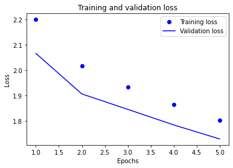

```python
# Plot training and validation loss

import matplotlib.pyplot as plt

loss_values = history_dict['loss']
val_loss_values = history_dict['val_loss']

epochs = range(1, len(loss_values) + 1)


plt.plot(epochs, loss_values, 'bo', label = 'Training loss')
plt.plot(epochs, val_loss_values, 'b', label = 'Validation loss')
plt.title('Training and validation loss')
plt.xlabel('Epochs')
plt.ylabel('Loss')
plt.legend()

plt.show()
```

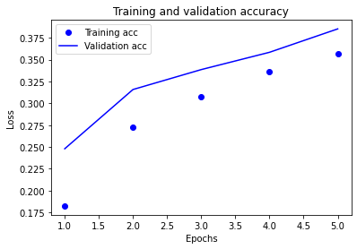

```python
# plot training and validation accuracy

plt.clf()
acc_values = history_dict['accuracy']
val_acc_values = history_dict['val_accuracy']

plt.plot(epochs, acc_values, 'bo', label = 'Training acc')
plt.plot(epochs, val_acc_values, 'b', label = 'Validation acc')
plt.title('Training and validation accuracy')
plt.xlabel('Epochs')
plt.ylabel('Loss')
plt.legend()

plt.show()
```

```python
#-------------------------------------
#EVALUATE ON TEST DATA
#-------------------------------------
train_loss, train_acc = model.evaluate(train_images, train_labels, batch_size=batch_size)
test_loss, test_acc = model.evaluate(test_images, test_labels, batch_size=test_images.shape[0])
print('train_acc:', train_acc)
print('test_acc:', test_acc)
```

```
train_acc: 0.3815000057220459
test_acc: 0.38839998841285706
```